# Peer Assesment-1

Kanika Kataria

15 November 2015

## Loading and preprocessing the data

```r
library(ggplot2)
library(plyr)
library(Hmisc)


Daily_activity <- read.csv("activity.csv")
Daily_activity$date <- as.POSIXct(Daily_activity$date)
```

## What is mean total number of steps taken per day?

#### For this part of the assignment, we can ignore the missing values in the dataset.

#### 1. Calculate the total number of steps taken per day

```r
Total_steps<-aggregate(Daily_activity$steps, by=list(Daily_activity$date),sum,na.rm=TRUE)
names(Total_steps)<-c("Date","TSteps") #calculation totla number of steps per day ignoring the na values
```

#### 2. Make a histogram of the total number of steps taken each day

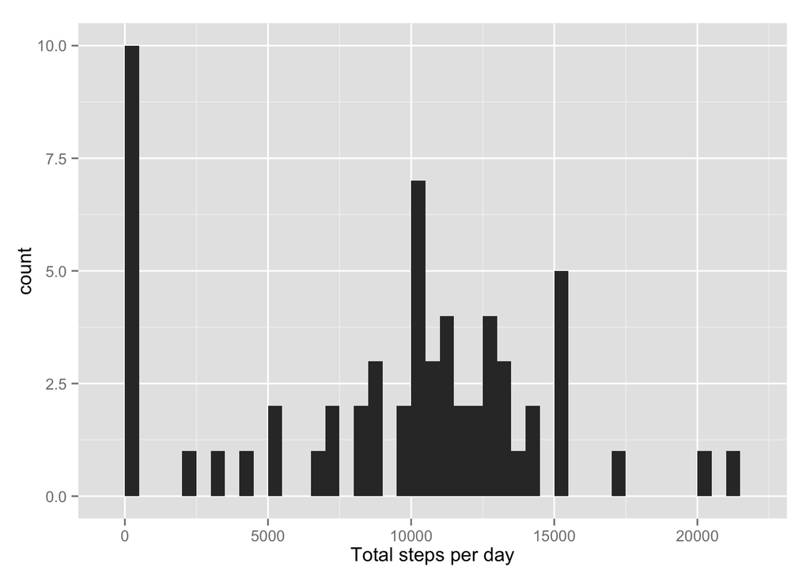

```r
qplot(TSteps,data=Total_steps,xlab='Total steps per day',binwidth=500) #plot the  histogram for steps per day or
```

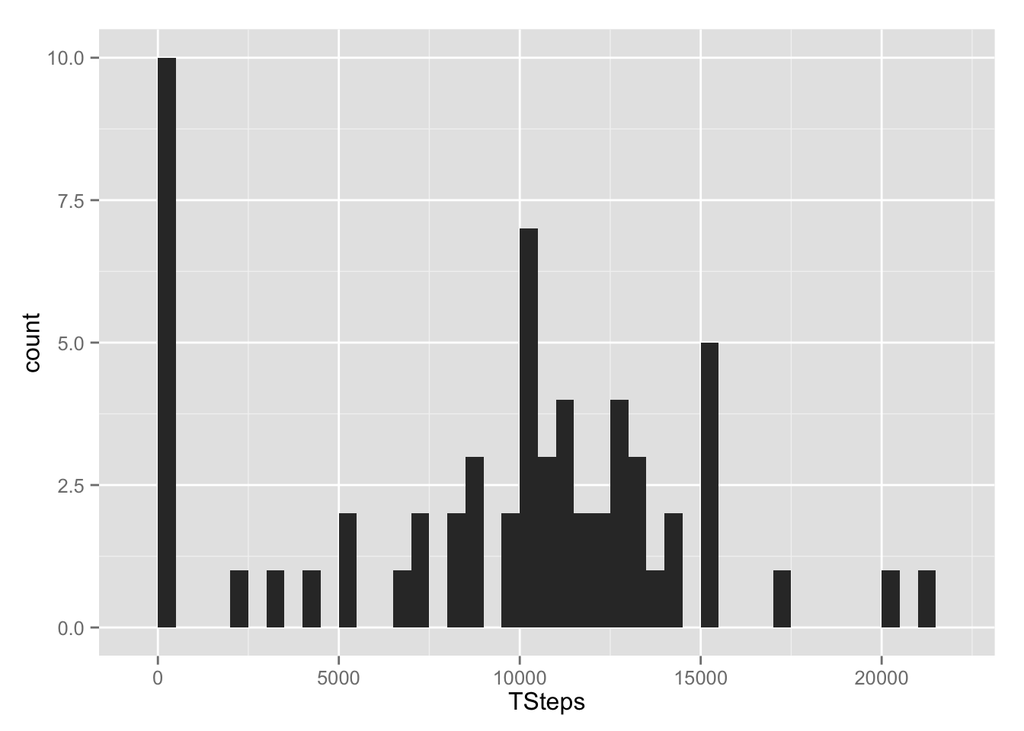

```r
ggplot(Total_steps, aes(x=TSteps)) + geom_histogram(binwidth=500)#plot the  histogram for steps per day
```

#### 3. Calculate and report the mean and median of the total number of steps taken per day

```r
stepsmean=mean(Total_steps$TSteps)#calculating the mean of total steps per day
stepsmedian=median(Total_steps$TSteps)# calculating the median of total steps per day
```

- Mean: 9354.2295082
- Median: 10395

## What is the average daily activity pattern?

#### 1. Make a time series plot (i.e. type = “l”) of the 5-minute interval (x-axis) and the average number of steps taken, averaged across all days (y-axis)

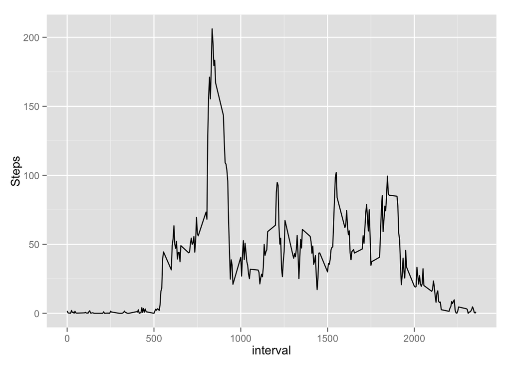

```r
avg_steps_interval<-aggregate(x=list(Steps=Daily_activity$steps),by=list(interval=Daily_activity$interval),FUN=mean,na.rm=TRUE)#calculating the average of total steps per interval
ggplot(avg_steps_interval,aes(x=interval,y=Steps))+geom_line()
```

```r
# plotting the time series plot for average steps per interval
```

#### 2. Which 5-minute interval, on average across all the days in the dataset, contains the maximum number of steps?

```r
most_steps <- which.max(avg_steps_interval$Steps)
Most_steps_interval <-  gsub("([0-9]{1,2})([0-9]{2})", "\\1\\2", avg_steps_interval[most_steps,'interval'])# Evaluating the interval with maximum number of steps
```

- Interval with maximum number of steps: 835

## Imputing missing values

#### 1. Calculate and report the total number of missing values in the dataset (i.e. the total number of rows with NAs)

```r
Total_na_rows<-sum(is.na(Daily_activity))# Evaluating total number of rows containing NA values
```

- total number of rows containing NA values:2304

#### 2. Devise a strategy for filling in all of the missing values in the dataset. The strategy does not need to be sophisticated. For example, you could use the mean/median for that day, or the mean for that 5-minute interval, etc.

#### 3. Create a new dataset that is equal to the original dataset but with the missing data filled in.

```r
Daily_imputed_activity<- Daily_activity
Daily_imputed_activity$steps<-impute(Daily_activity$steps,fun=median)
```

#### 4. Make a histogram of the total number of steps taken each day

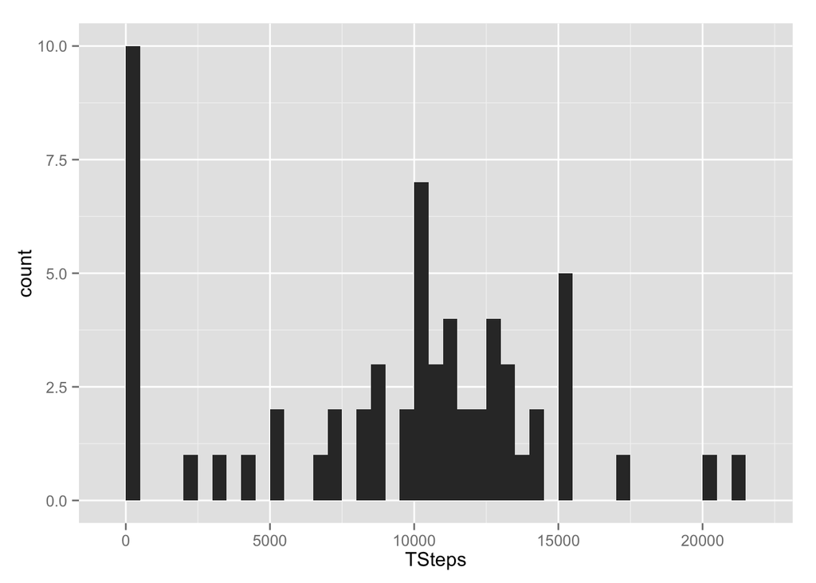

```r
Total_imputed_steps<-aggregate(Daily_imputed_activity$steps, by=list(Daily_imputed_activity$date),sum,na.rm=TRUE)
names(Total_imputed_steps)<-c("Date","TSteps") #calculation total number of steps per day ignoring the na values
ggplot(Total_imputed_steps, aes(x=TSteps)) + geom_histogram(binwidth=500)#
```

```r
steps_imputed_mean=mean(Total_imputed_steps$TSteps)#calculating the mean of total steps per day
steps_imputed_median=median(Total_imputed_steps$TSteps)# calculating the median of total steps per day
```

## Are there differences in activity patterns between weekdays and weekends?

#### 1.Create a new factor variable in the dataset with two levels ??? ???weekday??? and ???weekend??? indicating whether a given date is a weekday or weekend

```r
Daily_imputed_activity$weekdayType <- ifelse(weekdays(Daily_imputed_activity$date) %in% c("Satuday", "Sunday"),
    "weekend", "weekday")
    head(Daily_imputed_activity)
```

```
##   steps       date interval weekdayType
## 1     0 2012-10-01        0     weekday
## 2     0 2012-10-01        5     weekday
## 3     0 2012-10-01       10     weekday
## 4     0 2012-10-01       15     weekday
## 5     0 2012-10-01       20     weekday
## 6     0 2012-10-01       25     weekday
```

#### 2.Make a panel plot containing a time series plot (i.e. type = ???l???) of the 5-minute interval (x-axis) and the average number of steps taken, averaged across all weekday days or weekend days (y-axis).

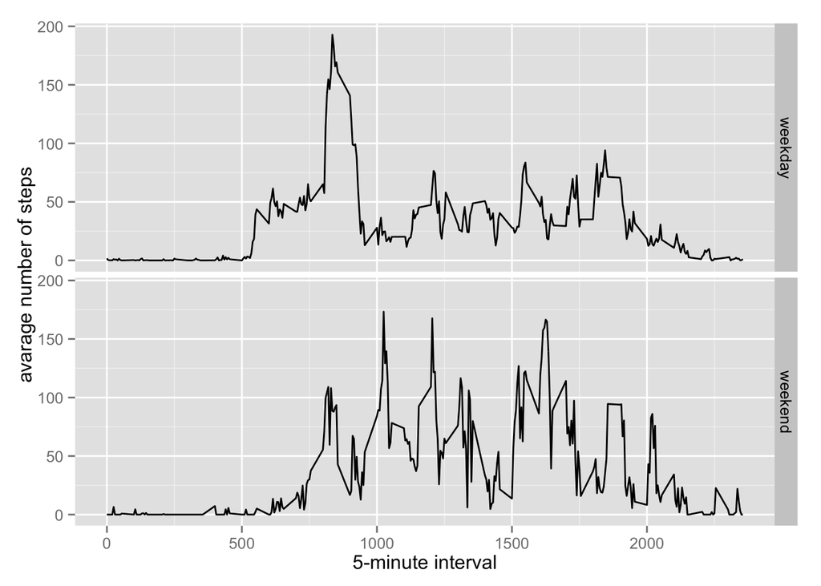

```r
averagedActivityDataImputed <- aggregate(steps ~ interval +weekdayType , data=Daily_imputed_activity, mean)
ggplot(averagedActivityDataImputed, aes(interval, steps)) +
    geom_line() +
    facet_grid(weekdayType ~ .) +
    xlab("5-minute interval") +
    ylab("avarage number of steps")
```